# Chapter2

The Caveman Coder

2025-10-27

Two Flavors of Spatial Data: 1. Vector Data - Drawing with precision using points, linestrings, and polygon objects. 2. Raster Data - Rendering a map using colored squares (pixels), like a digital photograph.

Standard tools: `sf` for vector data, `terra` for raster data.

Examples: Want to map road networks precisely? Vector (`sf`). Want to show elevation across a landscape? Raster (`terra`). Want to calclate the length of a river? Vector (`sf`). Want to analyze satellite imagery? Raster (`terra`).

Parts of an `sf` object: 1. The attribute table: similar to a regular data frame that holds information about each feature. Examples: country name, road name, etc. 2. The geometry column: contains one special column usually named `geometry` holds the actual spatial information. Examples: `POINT`, `LINESTRING`, and `POLYGON`.

The Coordinate Reference System

Problem: The earth is round and maps are flat. How do we represent locations accurately?

The **datum** tells us how to mathematically model the Earth’s imperfect shape. The earth is not a perfect sphere because; is has more bulge at the equator and more flattening at the poles. The datum defines an origin pont (like the Earth’s center) and orientation.

Example: WGS84 (World Geodetic System 1984) – this is a global datum commonly used for storing geospatial data. Used by GPS.

Analogy: Choosing which slightly impefect orange model to use as reference before you start peeling.

The **Projection** defines how to mathematically translate the coordinates from the curved datum surface onto a flat map.

Analogy: Flattening the orange peel.

All projections introduce some kind of distorsion because it is impossible to perfectly flatten a curved surface without stretvhing, tearing, or squashing something.

**Conformal Projections** preserve local shapes and angles correctly. Examples: Mercator projection, Lambert conformal conic projection.

**Equal-Area Projections** preserve the area of the features across the map, but distort shapes, angles, and distances. Example: Albers Equal Area projection, Mollewide projection, Eckert IV projection.

**Equidistant Projections** preserve distances correctly from one or two central points to all other points, but distort shape and area elsewhere.

**Azimuthal Projections** preserve direction correctly form a central point. Example: Mecca Projection.

Why is CRS critical? - Alignment: When data layers are overlaid on a map, the features must line up.  
- Analysis: When we need to calculate something (like distance or area).  
- Appearance: The choice of projection affects how the map looks.

CRSs are often identified by unique codes. Examples: - EPSG:4326 - One of the most common CRS codes. Managed by the European Petroleum Survey Group. Uses degrees as units.  
- EPSG:3587 - The code for the Web Mercator Projection used by Google Maps and OpenStreeMap. Uses meters as units, these distances are only accurate near the equator.  
- UTM Zones (e.g., EPSG:32632 for UTM Zone 32N) - divides the world into 60 narrow zones, where each zone has its own projected CRS and is designed to be accurate (low distorsion in shape, area, distance) within that specific zone. Units are in meters. Exellent for local and regional mapping and analysis.  
- National/Continental Grids (EPSG:5070 for USA Albers Equal Area, EPSG:28992 for Dutch National Grid) - Official projected CRSs of some countries or continents. Designed for accuracy within their boundaries. Units can be in meters or feet.

For more information on EPSG codes, go to https://epsg.io/.

Every spatial dataset has a CRS (Datum + Projection). As demonstrated in Chapter 1, we can use `st_crs()` to check and `st_transform()` to change CRS, often using standard EPSG codes.

Common spatial file formats:  
- Shapefile (.shp, etc.): The old workhorse. Composed of several files that must be located in the same folder. Lose one file and the whole dataset breaks.  
- GeoJSON (.geojson): Modern text-based format. Stores everything in one human-readable file.  
- GeoPackage (.gpkg): The modern, open standard designed to replace shapefiles. Stores everything in a single file. Easier to manage and share.  
- GeoTIFF (.tif): The standard for raster data.  
- CSV (.csv, .txt): Often used to store lat-long columns, does not store CRS information. The user must tell R explicitly what system to use (usually `crs = 4326` for standard Lat/Lon data).

## Hands-on Exercise

**Load Packages and Data**

Step 1: Load necessary packages

```r
pacman::p_load(sf, rnaturalearth, tidyverse)
```

Step 2: Get world countries data as an `sf` object

```r
world_countries <- rnaturalearth::ne_countries(
  scale = "medium", returnclass = "sf"
)
```

Step 3: Get world cities data as an `sf` object

```r
world_cities <- rnaturalearth::ne_download(
  scale       = "medium",
  type        = "populated_places",
  category    = "cultural",
  returnclass = "sf"
)
```

```
## Reading 'ne_50m_populated_places.zip' from naturalearth...
```

**Inspect the `sf` Object Structure**

Step 4: Print the whole object - see the table + geometry

```r
print(world_countries)
```

```
## Simple feature collection with 242 features and 168 fields
## Geometry type: MULTIPOLYGON
## Dimension:     XY
## Bounding box:  xmin: -180 ymin: -89.99893 xmax: 180 ymax: 83.59961
## Geodetic CRS:  WGS 84
## First 10 features:
##         featurecla scalerank labelrank                     sovereignt sov_a3
## 1  Admin-0 country         1         3                       Zimbabwe    ZWE
## 2  Admin-0 country         1         3                         Zambia    ZMB
## 3  Admin-0 country         1         3                          Yemen    YEM
## 4  Admin-0 country         3         2                        Vietnam    VNM
## 5  Admin-0 country         5         3                      Venezuela    VEN
## 6  Admin-0 country         6         6                        Vatican    VAT
## 7  Admin-0 country         1         4                        Vanuatu    VUT
## 8  Admin-0 country         1         3                     Uzbekistan    UZB
```

[output cut: 343 more lines]

Note that the last column is `geometry` and it shows the CRS info and geometry type.

Step 5: Check the class - what kind of object is it?

```r
print(class(world_countries))
```

```
## [1] "sf"         "data.frame"
```

It is both a data frame and an`sf` object.

Step 6. Use `glimpse()` for a compact summary of attributes

```r
dplyr::glimpse(world_countries)
```

```
## Rows: 242
## Columns: 169
## $ featurecla <chr> "Admin-0 country", "Admin-0 country", "Admin-0 country", "A…
## $ scalerank  <int> 1, 1, 1, 3, 5, 6, 1, 1, 1, 3, 5, 3, 3, 3, 3, 1, 5, 3, 3, 3,…
## $ labelrank  <int> 3, 3, 3, 2, 3, 6, 4, 3, 4, 6, 6, 6, 6, 6, 4, 5, 2, 4, 5, 6,…
## $ sovereignt <chr> "Zimbabwe", "Zambia", "Yemen", "Vietnam", "Venezuela", "Vat…
## $ sov_a3     <chr> "ZWE", "ZMB", "YEM", "VNM", "VEN", "VAT", "VUT", "UZB", "UR…
## $ adm0_dif   <int> 0, 0, 0, 0, 0, 0, 0, 0, 0, 0, 0, 1, 1, 1, 1, 1, 1, 1, 1, 1,…
## $ level      <int> 2, 2, 2, 2, 2, 2, 2, 2, 2, 2, 2, 2, 2, 2, 2, 2, 2, 2, 2, 2,…
## $ type       <chr> "Sovereign country", "Sovereign country", "Sovereign countr…
## $ tlc        <chr> "1", "1", "1", "1", "1", "1", "1", "1", "1", "1", "1", "1",…
## $ admin      <chr> "Zimbabwe", "Zambia", "Yemen", "Vietnam", "Venezuela", "Vat…
## $ adm0_a3    <chr> "ZWE", "ZMB", "YEM", "VNM", "VEN", "VAT", "VUT", "UZB", "UR…
## $ geou_dif   <int> 0, 0, 0, 0, 0, 0, 0, 0, 0, 0, 0, 0, 0, 0, 0, 0, 0, 0, 0, 0,…
## $ geounit    <chr> "Zimbabwe", "Zambia", "Yemen", "Vietnam", "Venezuela", "Vat…
```

[output cut: 156 more lines]

Step 7: Look at JUST the attribute table (aka remove the geometry column)

```r
world_attributes_only <- sf::st_drop_geometry(world_countries)
head(world_attributes_only)
```

```
##        featurecla scalerank labelrank sovereignt sov_a3 adm0_dif level
## 1 Admin-0 country         1         3   Zimbabwe    ZWE        0     2
## 2 Admin-0 country         1         3     Zambia    ZMB        0     2
## 3 Admin-0 country         1         3      Yemen    YEM        0     2
## 4 Admin-0 country         3         2    Vietnam    VNM        0     2
## 5 Admin-0 country         5         3  Venezuela    VEN        0     2
## 6 Admin-0 country         6         6    Vatican    VAT        0     2
##                type tlc     admin adm0_a3 geou_dif   geounit gu_a3 su_dif
## 1 Sovereign country   1  Zimbabwe     ZWE        0  Zimbabwe   ZWE      0
## 2 Sovereign country   1    Zambia     ZMB        0    Zambia   ZMB      0
## 3 Sovereign country   1     Yemen     YEM        0     Yemen   YEM      0
## 4 Sovereign country   1   Vietnam     VNM        0   Vietnam   VNM      0
## 5 Sovereign country   1 Venezuela     VEN        0 Venezuela   VEN      0
## 6 Sovereign country   1   Vatican     VAT        0   Vatican   VAT      0
##     subunit su_a3 brk_diff      name name_long brk_a3  brk_name brk_group
```

[output cut: 174 more lines]

```r
class(world_attributes_only)
```

```
## [1] "data.frame"
```

Step 8: Look at JUST the geometry column

```r
world_geometry_only <- sf::st_geometry(world_countries)
head(world_geometry_only)
```

```
## Geometry set for 6 features
## Geometry type: MULTIPOLYGON
## Dimension:     XY
## Bounding box:  xmin: -73.36621 ymin: -22.40205 xmax: 109.4449 ymax: 41.9062
## Geodetic CRS:  WGS 84
## First 5 geometries:
```

```
## MULTIPOLYGON (((31.28789 -22.40205, 31.19727 -2...
```

```
## MULTIPOLYGON (((30.39609 -15.64307, 30.25068 -1...
```

```
## MULTIPOLYGON (((53.08564 16.64839, 52.58145 16....
```

```
## MULTIPOLYGON (((104.064 10.39082, 104.083 10.34...
```

```
## MULTIPOLYGON (((-60.82119 9.138379, -60.94141 9...
```

```r
class(world_geometry_only)
```

```
## [1] "sfc_MULTIPOLYGON" "sfc"
```

Note: sfc stands for simple feature colummn.

Step 9: Check the CRS again!

```r
sf::st_crs(world_countries)
```

```
## Coordinate Reference System:
##   User input: WGS 84
##   wkt:
## GEOGCRS["WGS 84",
##     DATUM["World Geodetic System 1984",
##         ELLIPSOID["WGS 84",6378137,298.257223563,
##             LENGTHUNIT["metre",1]]],
##     PRIMEM["Greenwich",0,
##         ANGLEUNIT["degree",0.0174532925199433]],
##     CS[ellipsoidal,2],
##         AXIS["latitude",north,
##             ORDER[1],
##             ANGLEUNIT["degree",0.0174532925199433]],
##         AXIS["longitude",east,
##             ORDER[2],
##             ANGLEUNIT["degree",0.0174532925199433]],
##     ID["EPSG",4326]]
```

Step 10: Transform `world_countries` to Robinson projection again

```r
target_crs_robinson <- "ESRI:54030" # Robinson CRS code
world_countries_robinson <- world_countries |>
  sf::st_transform(crs = target_crs_robinson)
```

Step 11: Check the NEW CRS

```r
sf::st_crs(world_countries_robinson)
```

```
## Coordinate Reference System:
##   User input: ESRI:54030
##   wkt:
## PROJCRS["World_Robinson",
##     BASEGEOGCRS["WGS 84",
##         DATUM["World Geodetic System 1984",
##             ELLIPSOID["WGS 84",6378137,298.257223563,
##                 LENGTHUNIT["metre",1]]],
##         PRIMEM["Greenwich",0,
##             ANGLEUNIT["Degree",0.0174532925199433]]],
##     CONVERSION["World_Robinson",
##         METHOD["Robinson"],
##         PARAMETER["Longitude of natural origin",0,
##             ANGLEUNIT["Degree",0.0174532925199433],
##             ID["EPSG",8802]],
##         PARAMETER["False easting",0,
##             LENGTHUNIT["metre",1],
##             ID["EPSG",8806]],
##         PARAMETER["False northing",0,
##             LENGTHUNIT["metre",1],
##             ID["EPSG",8807]]],
##     CS[Cartesian,2],
##         AXIS["(E)",east,
##             ORDER[1],
##             LENGTHUNIT["metre",1]],
##         AXIS["(N)",north,
##             ORDER[2],
##             LENGTHUNIT["metre",1]],
##     USAGE[
##         SCOPE["Not known."],
##         AREA["World."],
##         BBOX[-90,-180,90,180]],
##     ID["ESRI",54030]]
```

Step 12: Plot comparison using `ggplot`

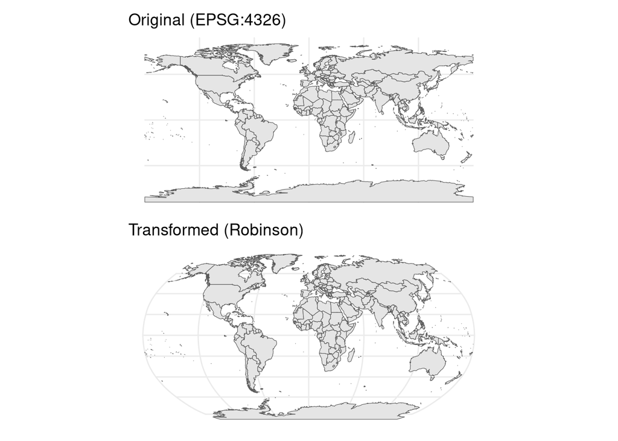

```r
plot_original <- ggplot() +
  geom_sf(
    data = world_countries,
    linewidth = 0.2
  ) +
  ggtitle("Original (EPSG:4326)") +
  theme_minimal()

plot_transformed <- ggplot() +
  geom_sf(
    data = world_countries_robinson,
    linewidth = 0.2
  ) +
  ggtitle("Transformed (Robinson)") +
  theme_minimal()

# Arrange the plots side-by-side using the `patchwork` package
pacman::p_load(patchwork)
plot_original / plot_transformed
```